# Use Case: Ruminant data

Anabella Lozza

anabellalozza@agro.unlpam.edu.ar

Edward Garcia

E.H.Garcia@cgiar.org

2025-02-04

> This paper is a refinement of the ERA dataset use case by *Joshi, N.; Steward, P. and Rosenstock, Todd (2024)* in **“Guide to Livestock Data Analysis in the ERA Dataset”**

# Use Case: Understanding the impact of tree fodders on feed intake and weight gain

This project involves retrieving, exploring, and analysing the data provided in the ERAg R Package, “Evidence for Resilient Agriculture” (version 1.0.3.0; https://alliancebioversityciat.org/publications-data/erag-r-package-evidence-resilient-agriculture-v1030) to conduct a meta-analysis study to evaluate the effects of supplementing different species of tropical tree foliages in ruminants (cattle, sheep, and goats) on animal performance. To achieve this, we will follow these steps:

**1. Loading Required Libraries and Functions**

**2.Data Cleaning and Filtering**

*2.1 Sub-setting the data to specific livestock (e.g., cattle, sheep, goats) and practices involving tree fodder supplementing.*

*2.2 Harmonizing Units: Converts weight units (e.g., kg to g per individual per day) for consistent analysis.*

**3. Combining data.**

**4. Plotting simple figures**

*4.1 Plotting weight gain distribution with outliers*

*4.2 Plotting weight gain distribution without outliers*

**5. Effects of tree fodder feed from Random Effect Models**

*5.1 Loading Required Libraries and Functions*

*5.2 Data cleaning and subsetting data to meta analysis*

*5.3. Estimates to Meta analysis*

*5.4. Plotting the effects*

## 1. Loading and saving the data

This section retrieves the most recent version of the livestock dataset from an S3 bucket. It lists the available files, downloads the required .RData file, and loads it into R using miceadds::load.Rdata2. The objective is to prepare the dataset (livestock_metadata) for analysis.

```r
# First we need to get the detailed dataset containing the management information that relates to the experiment, this is in the Atlas S3 Bucket

  dl_dir<-"downloaded_data"
  s3<-s3fs::S3FileSystem$new(anonymous = T)
  era_s3<-"s3://digital-atlas/era"

  # List the files in the s3 bucket
  files<-s3$dir_ls(file.path(era_s3,"data"))
  # This is the most recent version of the datas3://digital-atlas/era/data/skinny_cow_2022-YYYY-MM-DD.RData (substitute most recent date into filepath)
  files<-tail(grep(".RData",grep("skinny_cow_2022",files,value=T),value=T),1)

  # Set a save location for the dataset (amend to something more suitable for your needs)
  save_path<-file.path(getwd(),dl_dir,basename(files))

  if(!file.exists(save_path)){
    s3$file_download(files,save_path,overwrite = T)
  }

  livestock_metadata<- miceadds::load.Rdata2(file=basename(save_path),path=dirname(save_path))
```

## 2. Data cleaning and subsetting

### 2.1 Subsetting the data

Section focuses on filtering the dataset to a specific scope for analysis. It begins by identifying subpractices related to “Feed Addition” and “Feed Substitution” within the “Animals” theme, specifically those involving agroforestry. The data is then narrowed to livestock types of interest, such as cattle, goats, and sheep, and further refined to focus on key productivity outcomes, including “Meat Yield,” “Weight Gain,” and “Milk Yield.” A final filtering is performed by tree species of interest. Confounding practices, such as “Concentrates” and “Feed Crop,” are excluded to improve data quality.

```r
focal_pracs<-PracticeCodes[Practice %in% c("Feed Addition","Feed Substitution")
                            & grepl("Agrofor",Subpractice),Code]

data<-ERA.Compiled[grepl(paste(focal_pracs,collapse = "|"),plist)]

# List the files in the s3 bucket
files<-s3$dir_ls(file.path(era_s3,"data"))
# This should be the most recent version of the data era_compiled-v1.0_2018-v1.1_2020-skinny_cow_2022_YYYY_MM_DD.parquet
files<-tail(grep("parquet",grep("era_compiled",files,value=T),value=T),1)

# Set a save location for the dataset (amend to something more suitable for your needs)
save_path<-file.path(getwd(),dl_dir,basename(files))

if(!file.exists(save_path)){
  s3$file_download(files,save_path,overwrite = T)
}

ERA.Compiled_new<-arrow::read_parquet(save_path)
data_new<-ERA.Compiled_new[Version=="skinny_cow_2022" & grepl(paste(focal_pracs,collapse = "|"),plist)]

# Remove confounding subpractices
data_new<-data_new[!grepl("Concentrates|Feed Crop|Breed|Feed NonCrop",SubPrName)]

# The newer dataset on the s3 should be superior to old dataset so let's use it
data<-data_new

# Remove mechanical processing (this is just going to be chopping tree forages, probably not of interest)
  data[,SubPrName:=gsub("-Feed Mech Process|-Grazing Cut & Carry","",SubPrName)]

# Looking at any practices than involve tree fodder addition or substitution
  data<-data[,tree_fodder_add:=F][grepl("Feed AgFor (Add)",SubPrName,fixed=T),tree_fodder_add:=T]
  data<-data[,tree_fodder_sub:=F][grepl("Feed AgFor (Sub)",SubPrName,fixed=T),tree_fodder_sub:=T]

# 1.2) Subset to cattle and small ruminants #####
  focal_prods<-c("Cattle","Goat","Sheep")

  data <- data |> filter(Product.Simple %in% focal_prods)

# 1.3) Subset to outcomes of interest  #####
  focal_out<-c("Meat Yield","Weight Gain","Milk Yield")

   data <- data |> filter(Out.SubInd %in% focal_out)

# 1.4) Subset to tree of interest  #####
  focal_tree<-c("Acacia angustissima", "Acacia brevispica", "Acacia etbaica", " Acacia karroo", "Acacia polyacantha", "Acacia saligna", "Acacia senegal", "Adansonia digitata", "Afzelia africana", "Albizia gummifera", "Albizia harveyi", "Annona senegalensis", "Atriplex nummularia", "Azadirachta indica", "Calliandra calothyrsus", "Chamaecytisus palmensis", "Combretum apiculatum", "Daniellia oliveri", "Delonix elata", "Dichrostachys cinerea", "Erythrina brucei", "Euclea schimperi", "Faidherbia albida", "Ficus natalensis", "Ficus polita", "Ficus thonningii", "Gliciridia sepium", "Gmelina arborea", "Grewia similis", "Harissonia abyssinica", "Jatropha curcas", "Khaya senegalensis", "Leucaena leucocephala", "Leucaena padilla", "Leucaena pallida", "Moringa oleifera", "Moringa stenopetala","Olea europaea", "Opuntia ficus indica", "Piliostigma thonningii", "Pithecellobium dulce", "Prosopis juliflora", "Psophocarpus scandens", "Pterocarpus erinaceus", "Pterocarpus lucens", "Sesbania goetzei", "Sesbania sesban", "Sesbania sp", "Terminalia sericea", "Vachellia nilotica", "Vachellia sieberiana", "Vachellia tortilis")

   data <- data |> filter(Tree.Feed %in% focal_tree)
```

### 2.2 Harmonizing units

Unit harmonization is essential when studying livestock papers to ensure consistency and comparability across diverse datasets. In livestock research, data on outcomes like feed intake or weight gain are often reported in various units, such as kilograms (kg), grams per individual per day (g/individual/day), or other measurement standards. Without harmonization, direct comparisons or meta-analyses become challenging, as the variability in units can introduce bias or inaccuracies in the interpretation of results. By standardizing units, such as converting weight data from kg to g/day or normalizing by the duration of the study, researchers can create a uniform dataset. This allows for meaningful cross-study comparisons, improved statistical analysis, and clearer insights into the impacts of specific practices on livestock productivity, such as weight gain or feed efficiency.

```r
# Harmonize units #####
  data[Units %in% c("kg", "kg/individual", "kgt/individual") & !is.na(Duration),c("MeanT","MeanC","MeanT.Error","MeanC.Error","Units"):=.(round(1000*MeanT/(365*Duration),2),round(1000*MeanC/(365*Duration),2),round(1000*MeanT.Error/(365*Duration),2),round(1000*MeanC.Error/(365*Duration),2),"g/individual/day")
              ][Units=="kg/d/individual",c("MeanT","MeanC","MeanT.Error","MeanC.Error","Units"):=.(round(1000*MeanT,2),round(1000*MeanC,2),round(1000*MeanT.Error,2),round(1000*MeanC.Error,2),"g/individual/day")]

data <- data %>%
  mutate(Units = recode(Units,
                        "g/d/individual" = "g/individual/day",
                        "g/d" = "g/individual/day"))

#Remove inconsistent units
data<-data[!grepl("g/kg/individual|kg/individual|l/d/individual",Units)]
```

### 2.3 Exploring the subsetted data

After subsetting the data, you can explore the number of remaining papers that are within your research focus. The following table The table provides insights into the data coverage for different livestock practices, products, and outcomes. For example, “Feed Addition” applied to “Goat” for “Weight Gain” is reported in 15 studies with 46 observations from 6 countries. This information can help identify well-studied areas and data gaps in livestock research

|  | PrName | Product.Simple | Out.SubInd | no_studies | no_observations | no_countries |
| --- | --- | --- | --- | --- | --- | --- |
| 1 | Feed Addition | Goat | Weight Gain | 15 | 46 | 6 |
| 2 | Feed Substitution | Goat | Weight Gain | 14 | 50 | 8 |
| 3 | Feed Substitution | Sheep | Weight Gain | 13 | 52 | 4 |
| 4 | Feed Addition | Sheep | Weight Gain | 11 | 46 | 3 |
| 5 | Feed Addition | Goat | Meat Yield | 9 | 61 | 5 |
| 6 | Feed Substitution | Goat | Meat Yield | 9 | 24 | 6 |
| 7 | Feed Substitution | Sheep | Meat Yield | 9 | 38 | 4 |
| 8 | Feed Addition | Cattle | Weight Gain | 7 | 23 | 4 |
| 9 | Feed Addition | Sheep | Meat Yield | 7 | 17 | 2 |
| 10 | Feed Addition | Cattle | Milk Yield | 4 | 5 | 3 |

[output cut: 16 more lines]

We can choose to explore the data in future detail. The table below shows the studies that looked at the impact of adding tree fodders to diets of cattle goat and sheep.

|  | Product.Simple | Out.SubInd | no_studies | no_observations | no_countries |
| --- | --- | --- | --- | --- | --- |
| 1 | Goat | Weight Gain | 17 | 52 | 7 |
| 2 | Sheep | Weight Gain | 12 | 49 | 3 |
| 3 | Goat | Meat Yield | 10 | 64 | 5 |
| 4 | Cattle | Weight Gain | 10 | 35 | 5 |
| 5 | Sheep | Meat Yield | 8 | 29 | 2 |
| 6 | Cattle | Meat Yield | 5 | 15 | 3 |
| 7 | Cattle | Milk Yield | 4 | 5 | 3 |
| 8 | Goat | Milk Yield | 1 | 2 | 1 |

The table below shows the studies that looked at the impact of substitution of other ingredient types with tree fodders to diets of cattle goat and sheep.

|  | Product.Simple | Out.SubInd | no_studies | no_observations | no_countries |
| --- | --- | --- | --- | --- | --- |
| 1 | Goat | Weight Gain | 16 | 56 | 8 |
| 2 | Sheep | Weight Gain | 16 | 62 | 6 |
| 3 | Sheep | Meat Yield | 12 | 64 | 6 |
| 4 | Goat | Meat Yield | 11 | 30 | 7 |
| 5 | Cattle | Milk Yield | 4 | 11 | 2 |
| 6 | Goat | Milk Yield | 4 | 10 | 2 |

## 3. Combining data: Combining feed intake and weight gain outcomes

This script (unhide) integrates feed intake and weight gain data for livestock to analyze the relationship between feed types, including tree species, and animal performance.

It starts by filtering the feed intake data to include only entire diets with non-missing values. Tree species associated with feed intake are then merged into the dataset.

Similarly, weight gain data for non-fish species is filtered, standardized by converting weight measurements into kilograms per day, and calculating the final weight (end weight) after a given period. The script then merges the feed intake data with the weight gain data using common identifiers.

This results in a unified dataset that combines feed intake (including tree species) with corresponding weight gain metrics for livestock, enabling detailed analysis of the impacts of different feed practices on animal growth.

```r
# 4.5) Feed Intake and Weight Gain with Tree Species #####

# Filter Feed Intake data to include only entire diets and remove NA values
feed_intake <- livestock_metadata$Data.Out[
  Out.Subind == "Feed Intake" & is_entire_diet == TRUE & !is.na(ED.Intake.Item),
  .(B.Code, T.Name, A.Level.Name, Out.Subind, ED.Intake.Item, ED.Mean.T, Out.Unit)
]


# Select only relevant columns for feed trees and rename
feed_trees <- data %>%
  select(Code, T.Descrip, Tree.Feed) %>%
  rename(`A.Level.Name` = T.Descrip, `B.Code` = Code)

# Merge feed intake with tree species data
feed_intake_trees <- merge(
  feed_intake,
  feed_trees,
  by = c("B.Code", "A.Level.Name"),
  all.x = TRUE  # Left join to retain all feed intake rows
)

# Filter Weight Gain data and remove no-focal products entries
WG <- livestock_metadata$Data.Out[
  Out.Subind == "Weight Gain" & P.Product %in% focal_prods,
  .(B.Code, P.Product, T.Name, A.Level.Name, Out.WG.Start, Out.WG.Unit, Out.WG.Days, ED.Mean.T, Out.Unit)
]

# Define units to standardize and convert Weight Gain data
units_per_day <- c(
      "g/day", "g", "g/d", "g/individual/day", "g/head/day", "g/day/individual",
      "g/d/individual", "g/individual/d", "g/indivividual/day", "g/individual",
      "g/ndividual/day", "g/dindividual/day", "g/individual.day", "g /individual/day"
    )

# Convert ED.Mean.T to kilograms/day only for specific units
    WG[, ED.Mean.T_kg := ifelse(
      Out.Unit %in% units_per_day,               # Check if Out.Unit is in the list
      round(ED.Mean.T / 1000, 3),                   # Convert grams/day to kilograms/day and round
      round(ED.Mean.T, 3)                           # Retain as is if not in the list
    )]

    # Convert Out.WG.Start to kilograms if Out.WG.Unit indicates grams
    WG[, Out.WG.Start_kg := ifelse(
      grepl("^g$", Out.WG.Unit, ignore.case = TRUE), # Match exact "g"
      Out.WG.Start / 1000,                          # Convert grams to kilograms
      Out.WG.Start                                   # Retain if already in kilograms
    )]

    # Calculate Out.WG.End
    WG[, Out.WG.End := ifelse(
      Out.Unit %in% units_per_day,                  # Daily gain units
      round(Out.WG.Start_kg + (ED.Mean.T_kg * Out.WG.Days), 3),
      ifelse(                                       # Non-daily gain units
        grepl("^(g|kg|Kg)$", Out.Unit, ignore.case = TRUE),
        round(Out.WG.Start_kg + ED.Mean.T_kg, 3),
        NA                                          # Set to NA for other units
      )
    )]
 #Merge with feed intake.
    # Rename columns in WG and feed intake datasets
    WG <- WG %>%
      rename(
        `Weight Gain` = ED.Mean.T,
        `Weight Gain Unit` = Out.Unit,
        `Weight Gain_kg` = ED.Mean.T_kg
      )

    feed_intake_trees <- feed_intake_trees %>%
      rename(
        `Feed Intake` = ED.Mean.T,
        `Feed Intake Unit` = Out.Unit,
      )

    # Perform an inner join on the common columns
    intake_WG <- merge(
      WG, feed_intake_trees,
      by = c("B.Code", "T.Name", "A.Level.Name"),
      all = FALSE # Inner join: retain only matching rows
    )

    intake_WG<- intake_WG %>%
      rename(`D.Item_raw`= ED.Intake.Item)

  # Display the summary table   of  diets
DT::datatable(
  intake_WG,
  options = list(
    scrollY = "400px",  # Set vertical scroll height
    scrollX = TRUE,     # Enable horizontal scrolling
    pageLength = 20,    # Initial number of rows displayed
    fixedHeader = FALSE  # Keep column headers fixed while scrolling
  )
)
```

|  | B.Code | T.Name | A.Level.Name | P.Product | Out.WG.Start | Out.WG.Unit | Out.WG.Days | Weight Gain | Weight Gain Unit | Weight Gain_kg | Out.WG.Start_kg | Out.WG.End | Out.Subind | D.Item_raw | Feed Intake | Feed Intake Unit | Tree.Feed |
| --- | --- | --- | --- | --- | --- | --- | --- | --- | --- | --- | --- | --- | --- | --- | --- | --- | --- |
| 1 | AG0042 | 60% F SOPM | 60% F SOPM | Goat | 9.72 | kg | 56 | 14.59 | g/d/individual | 0.015 | 9.72 | 10.56 | Feed Intake | 60% F SOPM | 312.5 | g/individual/day |  |
| 2 | AG0042 | 60% F SOPM | 60% F SOPM | Goat | 9.72 | kg | 56 | 14.59 | g/d/individual | 0.015 | 9.72 | 10.56 | Feed Intake | 60% F SOPM | 228.2 | g DM/individual/day |  |
| 3 | AG0042 | 60% UF SOPM | 60% UF SOPM | Goat | 9.25 | kg | 56 | 16.96 | g/d/individual | 0.017 | 9.25 | 10.202 | Feed Intake | 60% UF SOPM | 297.7 | g/individual/day |  |
| 4 | AG0042 | 60% UF SOPM | 60% UF SOPM | Goat | 9.25 | kg | 56 | 16.96 | g/d/individual | 0.017 | 9.25 | 10.202 | Feed Intake | 60% UF SOPM | 240.64 | g DM/individual/day |  |
| 5 | AG0042 | Con | Con | Goat | 9.83 | kg | 56 | 23 | g/d/individual | 0.023 | 9.83 | 11.118 | Feed Intake | Con | 312.4 | g/individual/day |  |
| 6 | AG0042 | Con | Con | Goat | 9.83 | kg | 56 | 23 | g/d/individual | 0.023 | 9.83 | 11.118 | Feed Intake | Con | 273.35 | g DM/individual/day |  |
| 7 | AN0007 | T1 | T1 | Sheep | 12.8 | kg | 56 | 30.35 | g/d/individual | 0.03 | 12.8 | 14.48 | Feed Intake | T1 | 330.1 | g DM/individual/day |  |
| 8 | AN0007 | T2 | T2 | Sheep | 13 | kg | 56 | 35.71 | g/d/individual | 0.036 | 13 | 15.016 | Feed Intake | T2 | 329.82 | g DM/individual/day | Gmelina arborea |
| 9 | AN0007 | T2 | T2 | Sheep | 13 | kg | 56 | 35.71 | g/d/individual | 0.036 | 13 | 15.016 | Feed Intake | T2 | 329.82 | g DM/individual/day | Gmelina arborea |
| 10 | AN0007 | T3 | T3 | Sheep | 13.2 | kg | 56 | 39.29 | g/d/individual | 0.039 | 13.2 | 15.384 | Feed Intake | T3 | 347.47 | g DM/individual/day | Gmelina arborea |

[output cut: 1347 more lines]

## 4. Plotting simple figures

### 4.1 Plotting weight gain distribution with outliers

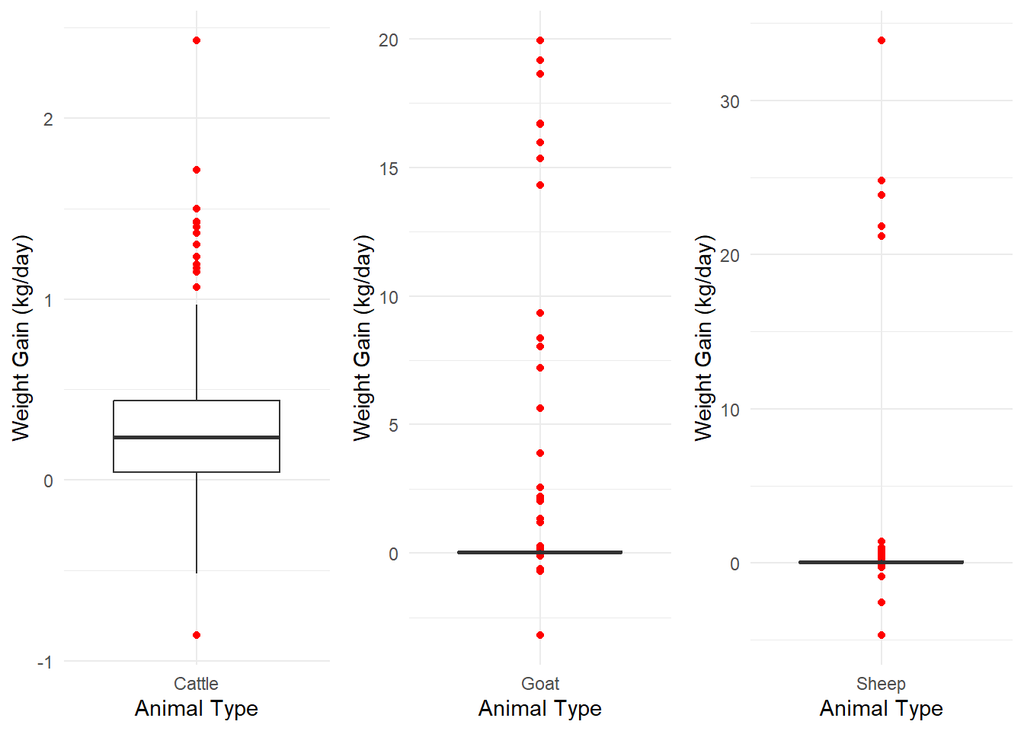

```r
# Function to filter data for all animals and include outliers
filter_all_animals <- function(data) {
  # Subset data for selected animals
  animal_data <- data[data$P.Product %in% c("Cattle", "Goat", "Sheep"), ]
  return(animal_data)
}

# Filter the data for all animals
animal_data_with_outliers <- filter_all_animals(WG)

# Create individual plots for each animal with outliers
plot_cattle <- ggplot(animal_data_with_outliers[animal_data_with_outliers$P.Product == "Cattle", ], aes(x = P.Product, y = `Weight Gain_kg`)) +
  geom_boxplot(outlier.color = "red", outlier.shape = 19) +
  labs(
    x = "Animal Type",
    y = "Weight Gain (kg/day)"
  ) +
  theme_minimal()

plot_goat <- ggplot(animal_data_with_outliers[animal_data_with_outliers$P.Product == "Goat", ], aes(x = P.Product, y = `Weight Gain_kg`)) +
  geom_boxplot(outlier.color = "red", outlier.shape = 19) +
  labs(
    x = "Animal Type",
    y = "Weight Gain (kg/day)"
  ) +
  theme_minimal()

plot_sheep <- ggplot(animal_data_with_outliers[animal_data_with_outliers$P.Product == "Sheep", ], aes(x = P.Product, y = `Weight Gain_kg`)) +
  geom_boxplot(outlier.color = "red", outlier.shape = 19) +
  labs(
    x = "Animal Type",
    y = "Weight Gain (kg/day)"
  ) +
  theme_minimal()

# Combine the plots into one image in landscape orientation
combined_plot <- grid.arrange(plot_cattle, plot_goat, plot_sheep, nrow = 1)
```

```r
# Display the combined plot
print(combined_plot)
```

### 4.2 Plotting weight gain distribution without outliers

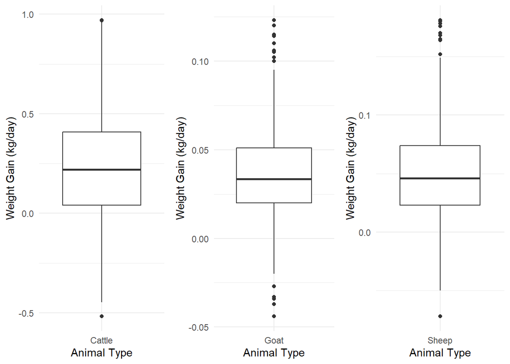

```r
library(ggplot2)
library(gridExtra)

# Function to filter data for all animals and remove outliers
filter_and_remove_outliers <- function(data) {
  # Subset data for selected animals
  animal_data <- data[data$P.Product %in% c("Cattle", "Goat", "Sheep"), ]

  # Remove outliers for each animal type
  animal_data <- animal_data %>%
    group_by(P.Product) %>%
    filter(
      `Weight Gain_kg` > quantile(`Weight Gain_kg`, 0.25, na.rm = TRUE) - 1.5 * IQR(`Weight Gain_kg`, na.rm = TRUE) &
      `Weight Gain_kg` < quantile(`Weight Gain_kg`, 0.75, na.rm = TRUE) + 1.5 * IQR(`Weight Gain_kg`, na.rm = TRUE)
    ) %>%
    ungroup()

  return(animal_data)
}

# Filter and remove outliers for all animals
animal_data <- filter_and_remove_outliers(WG)

# Create individual plots for each animal
plot_cattle <- ggplot(animal_data[animal_data$P.Product == "Cattle", ], aes(x = P.Product, y = `Weight Gain_kg`)) +
  geom_boxplot() +
  labs(
    x = "Animal Type",
    y = "Weight Gain (kg/day)"
  ) +
  theme_minimal()

plot_goat <- ggplot(animal_data[animal_data$P.Product == "Goat", ], aes(x = P.Product, y = `Weight Gain_kg`)) +
  geom_boxplot() +
  labs(
    x = "Animal Type",
    y = "Weight Gain (kg/day)"
  ) +
  theme_minimal()

plot_sheep <- ggplot(animal_data[animal_data$P.Product == "Sheep", ], aes(x = P.Product, y = `Weight Gain_kg`)) +
  geom_boxplot() +
  labs(
    x = "Animal Type",
    y = "Weight Gain (kg/day)"
  ) +
  theme_minimal()

# Combine the plots into one image in landscape orientation
combined_plot <- grid.arrange(plot_cattle, plot_goat, plot_sheep, nrow = 1)
```

```r
# Display the combined plot
print(combined_plot)
```

This script creates a data subset to visualize the effects of tree forage on weight gain in three livestock categories: “Cattle”, “Goat” and “Sheep”. The dataset is filtered to include only the most important tree species.

### 5.1 Loading Required Libraries and Functions

This section downloads the required R package to make the meta- analysis.

```r
options(repos = c(CRAN = "https://cran.rstudio.com/"))
install.packages("metafor")
library(metafor)
```

### 5.2. Data cleaning and subsetting data to meta analysis

Section focuses on filtering the dataset to a specific scope for meta-analysis. The data is then narrowed to livestock types of interest, cattle, goats, and sheep, and further refined to focus on key productivity outcome, specifically ” “Weight Gain”. The most representative tree species in the studies are also selected.

```r
# Select only relevant columns for meta analysis and most important trees feed
MA_data <- data %>%
  select(Code, Tree.Feed, Author, Date, Country, Units, MeanC, MeanT, MeanT.Error, Mean.Error.Type, MeanC.Error, Rep.Animals, Out.SubInd, SubPrName, PrName, Product.Simple) %>%
  filter(Tree.Feed %in% c("Leucaena leucocephala", "Sesbania sesban", "Atriplex nummularia", "Ficus thonningii", "Prosopis juliflora", "Gliciridia sepium", "Moringa oleifera", "Opuntia ficus indica", "Leucaena pallida", "Erythrina brucei")) %>%
  filter(Out.SubInd %in% c("Weight Gain"))

#Add Reference and DM column
MA_data <- MA_data %>%
  mutate(Reference = paste(Author, Date, sep = ", "))

#Transform character variables in numeric
MA_data$Rep.Animals <- as.numeric(MA_data$Rep.Animals)

#Separate tables by ruminant sp.
MA_dataCattle <- MA_data %>% filter(Product.Simple=="Cattle")
MA_dataGoat <- MA_data %>% filter(Product.Simple=="Goat")
MA_dataSheep <- MA_data %>% filter(Product.Simple=="Sheep")
```

### 5.3. Estimates to Meta analysis

This script estimates the raw mean difference (MD) by supplying control and treatment means (MeanC and MeanT), corresponding SE (MeanC.Error and MeanT.Error), and sample size (Rep.Animals) to compute the effect measure. It will create a new ” MAdat ” data set for each ruminant species. The NA values were removed.

```r
#Compute the effect measure, raw mean difference (MD) by supplying control and treatment means(MeanC and MeanT), corresponding SE (MeanC.Error and MeanT.Error), and sample size (Rep.Animals). This will create a new data set namely “MAdat”.

MAdatCattle <- escalc(m1i=MeanT, sd1i=MeanT.Error, n1i=Rep.Animals,
m2i=MeanC, sd2i=MeanC.Error, n2i=Rep.Animals,
measure="MD", data=MA_dataCattle,
append=TRUE)

MAdatGoat <- escalc(m1i=MeanT, sd1i=MeanT.Error, n1i=Rep.Animals,
m2i=MeanC, sd2i=MeanC.Error, n2i=Rep.Animals,
measure="MD", data=MA_dataGoat,
append=TRUE)

MAdatSheep <- escalc(m1i=MeanT, sd1i=MeanT.Error, n1i=Rep.Animals,
m2i=MeanC, sd2i=MeanC.Error, n2i=Rep.Animals,
measure="MD", data=MA_dataSheep,
append=TRUE)

#Compute standardized MD (SMD) for the forest plots
MAdatCattle2<- escalc(m1i=MeanT, sd1i=MeanT.Error, n1i=Rep.Animals,
m2i=MeanC, sd2i=MeanC.Error, n2i=Rep.Animals,
measure="SMD", data=MAdatCattle,
append=TRUE)

MAdatGoat2<- escalc(m1i=MeanT, sd1i=MeanT.Error, n1i=Rep.Animals,
m2i=MeanC, sd2i=MeanC.Error, n2i=Rep.Animals,
measure="SMD", data=MAdatGoat,
append=TRUE)

MAdatSheep2<- escalc(m1i=MeanT, sd1i=MeanT.Error, n1i=Rep.Animals,
m2i=MeanC, sd2i=MeanC.Error, n2i=Rep.Animals,
measure="SMD", data=MAdatSheep,
append=TRUE)

#Remove NA values
MAdatCattle2 <- MAdatCattle2 %>% filter(!is.na(yi))
MAdatGoat2 <- MAdatGoat2 %>% filter(!is.na(yi))
MAdatSheep2 <- MAdatSheep2 %>% filter(!is.na(yi))
```

### 5.4 Plotting the effects

A forest plot generated with the forest function shows the effects of tree fodder supplementation on ruminants sp in different studies.

Plotting the effects in **Cattle**

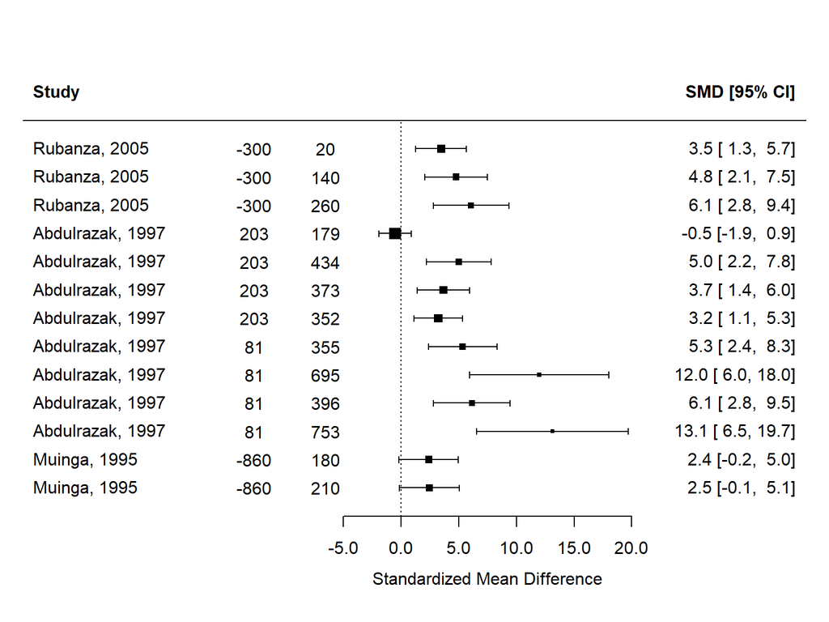

```r
#creating a forest plot Cattle using the SMD (using the “MAdat2” data)

forest(MAdatCattle2$yi, MAdatCattle2$vi,
       slab = MAdatCattle2$Reference,
       digits = 1,
       ilab= cbind(round(MAdatCattle2$MeanC),
round(MAdatCattle2$MeanT)))
```

Plotting the effects in **Goat**

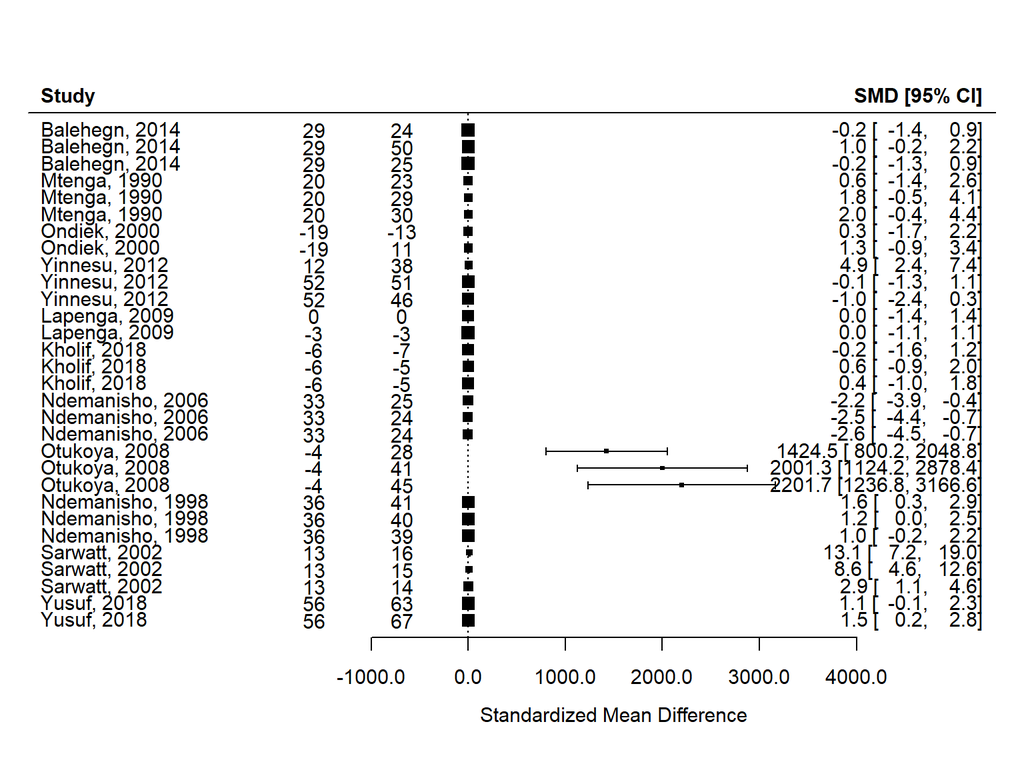

```r
#creating a forest plot Goat using the SMD (using the “MAdat2” data)

forest(MAdatGoat2$yi, MAdatGoat2$vi,
       slab = MAdatGoat2$Reference,
       digits = 1,
       ilab= cbind(round(MAdatGoat2$MeanC),
round(MAdatGoat2$MeanT)))
```

Plotting the effects in **Sheep**

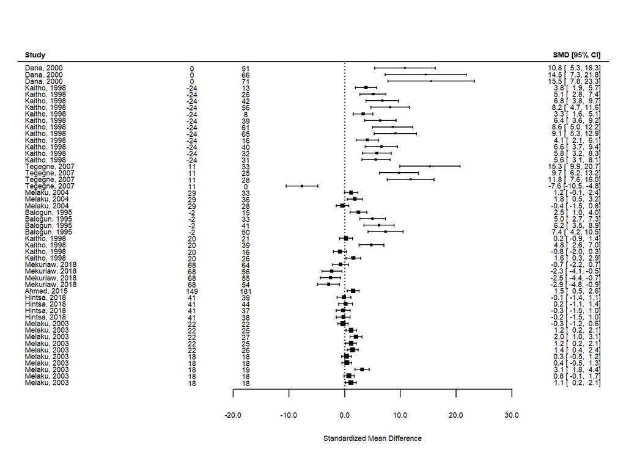

```r
#creating a forest plot Sheep using the SMD (using the “MAdat2” data)

forest(MAdatSheep2$yi, MAdatSheep2$vi,
       slab = MAdatSheep2$Reference,
       digits = 1,
       ilab= cbind(round(MAdatSheep2$MeanC),
round(MAdatSheep2$MeanT)))
```